# Formas de tenencia de la tierra y productividad agrícola rural en Ecuador

Una aproximación empírica de la eficiencia técnica mediante modelos de frontera estocástica de producción

José Vicente Ordóñez Yaguache

Escola de Doutoramento Internacional · Universidade de Santiago de Compostela

## La pregunta que guía esta investigación

¿Cómo se asocia el **régimen predominante de tenencia de la tierra** con la productividad de las UPA del Ecuador continental?

Tierravalor bruto estimado por hectárea

Trabajovalor bruto estimado por persona ocupada

Fronteraposición relativa frente a una frontera monetaria condicionada

La tesis pregunta por una **asociación**; no identifica el efecto causal de cambiar el régimen de una misma UPA.

## Propiedad, tenencia y seguridad no son equivalentes

01

### Propiedad

Régimen jurídico de dominio sobre la tierra.

→

02

### Tenencia

Condiciones de acceso, uso, control y transferencia.

→

03

### Seguridad

Estabilidad y protección efectiva de los derechos.

**Bruce (2000)** · **FIDA (2016)** · **Simbizi et al. (2014)** · **Cotula (2022)**

La ESPAC permite observar **formas de tenencia**; no mide directamente toda la seguridad jurídica ni la calidad contractual.

## ¿Por qué la tenencia podría relacionarse con la productividad?

Régimen de tenencia

↓

Horizonte de decisión

Protección de inversiones

Capacidad de transferencia

Acceso temporal a tierra

↓

Inversión

Tecnología e intensidad

Organización productiva

↓

Productividad

**Besley** · **Deininger** · **Feder** · **Fenske** · **Otsuka**

El mecanismo puede estar condicionado por **escala · capital humano · crédito · tecnología · mercados · territorio**.

## Ecuador llega a 2022 con una trayectoria agraria particular

**Formas comunitarias**derechos colectivos y uso comunal

**Colonia y República**concentración y persistencia del latifundio

**1964–1973**reformas agrarias

**Etapa contemporánea**regularización, catastro y mercados de tierras

La estructura contemporánea de la tenencia no surge en 2022: es el resultado de una **trayectoria histórica e institucional**.

Referencias de la tesis: Francescutti; Brassel et al.; MAGAP; Carrión.

## Una parte de la evidencia respalda el mecanismo de seguridad e inversión

| Estudio | Contexto | Resultado relevante |
| --- | --- | --- |
| **Feder et al. (1987)** | Tailandia | Seguridad de derechos, inversión y crédito. |
| **Besley (1995)** | Ghana | Determinados derechos se asocian con inversión. |
| **Ho (2021)** | Vietnam | Relación positiva con productividad, de magnitud moderada. |
| **Lawry et al. (2017)** | Revisión sistemática | Ganancias promedio en productividad e ingresos, con heterogeneidad. |

La literatura ofrece evidencia compatible con **derechos más seguros → mayores incentivos productivos**.

## Pero los resultados no son universales

| Estudio | Qué introduce en el debate |
| --- | --- |
| **Place et al. (1993)** | No encuentra una relación general entre derechos, insumos y rendimientos. |
| **Dickerman et al.** | Los efectos favorables aparecen solo en determinados contextos. |
| **Abdulai et al.** | Derechos consuetudinarios pueden sostener incentivos de inversión. |
| **Koirala et al. (2017)** | Arrendatarios presentan menor productividad/eficiencia en arroz filipino. |
| **Lawry et al. (2017)** | La heterogeneidad regional forma parte del resultado. |

El signo y la magnitud dependen del **contexto, el tipo de derecho y las restricciones productivas**.

## En Ecuador queda una pregunta específica abierta

### Conocemos bastante sobre…

- estructura agraria y fragmentación;
- reformas y regularización;
- catastro y seguridad jurídica;
- restricciones institucionales.

Carrión · MAGAP · Corral et al.

### Conocemos menos sobre…

las diferencias de productividad entre **regímenes efectivos de tenencia** con microdatos recientes y cobertura nacional.

Y menos aún cuando se consideran conjuntamente tierra, trabajo, territorio y una frontera condicionada.

## Pregunta, objetivo y alcance

Pregunta

¿Cómo se asocia el régimen predominante de tenencia con la productividad monetaria de la tierra y del trabajo y con la posición relativa frente a fronteras condicionadas?

Objetivo

Analizar esa asociación considerando escala, características de la persona productora, conectividad, prácticas tecnológicas y provincia.

**Alcance:** diseño cuantitativo, transversal y no experimental. Los resultados se interpretan como **asociaciones condicionadas**.

## ESPAC 2022: la base empírica

42.444

UPA en la base consolidada

Tenencia

Superficie

Cultivos

Pecuaria

Trabajo

Tecnología

Productor

Provincia

Unidad de análisis: **UPA del Ecuador continental**.

Fuente principal: Encuesta de Superficie y Producción Agropecuaria Continua (ESPAC) 2022, INEC.

## El problema que los datos no resolvían por sí solos

Cacaokg

≠

Lechelitros

≠

Bananocajas / kg

≠

Ganadocabezas / peso

≠

Florestallos / unidades

¿Cómo comparar económicamente UPA que producen bienes físicamente diferentes?

## Construimos la pieza que faltaba: una base de precios agropecuarios

**SIPA / MAG**productor · agroindustria · pecuario · mayoristas · bodegas · referencias internacionales

→

**> 25 bases**formatos y unidades heterogéneos

→

**Depuración**nombres · formatos · faltantes

→

**Homologación**productos · presentaciones · conversiones

→

**Precio 2022 comparable**trazable por producto y fuente

Trazabilidad real documentada en el Anexo A

| Elemento | Registro documentado |
| --- | --- |
| Fuente institucional | **SIPA** |
| Entidad responsable | Ministerio de Agricultura y Ganadería del Ecuador |
| Formato original | Archivos Excel |
| Carpeta reproducible | `data/external/sipa/archivos_excel/` |
| Script de descarga | `R/03-descargar-precios-sipa.R` |

Fuente: Anexo A de la tesis doctoral (trazabilidad de los archivos de precios agropecuarios).

La productividad monetaria exigió construir primero una **infraestructura de medición reproducible**.

## De producción física a producción económica comparable

Cantidad física

×

Precio de referencia 2022

=

Valor bruto estimado

↓ agregación por UPA

PT

Valor bruto estimado / hectáreas

USD/ha

PL

Valor bruto estimado / personas ocupadas

USD/persona

**Valor bruto estimado ≠ ingreso neto ≠ beneficio.** No se descuentan costos de producción, transporte o comercialización.

## ¿Cómo representamos la tenencia de una UPA?

### Una UPA puede combinar terrenos

DirectaArrendadaPosesión / otras

↓

Sumar superficie por modalidad → calcular participación → asignar la categoría de mayor superficie

Tenencia directa

Arrendamiento y aparceríacategoría de referencia

Otros regímenes

“Régimen predominante” resume la UPA; no describe exhaustivamente todos sus derechos ni contratos.

## De 42.444 UPA a muestras comparables

**42.444**productividad de la tierra disponible

**30.502**tierra + trabajo

**26.392**educación válida + covariables básicas

**22.075**muestra común OLS + multinivel

**21.430**ambas productividades > 0 · SFA

Cada reducción responde a un **criterio explícito de comparabilidad**, no a una depuración discrecional.

## Una pregunta, tres lentes complementarias

OLS + HC1

### ¿Persiste la asociación en la media?

Asociaciones promedio condicionadas.

Multinivel

### ¿Cuánto importa compartir territorio?

Variación entre UPA y provincias.

SFA

### ¿Dónde se ubican las UPA frente a una frontera?

Posición relativa condicionada.

La **tenencia** es el hilo común. Los tres métodos responden preguntas distintas; sus parámetros no son equivalentes.

## La prueba se construye progresivamente

**M1**Tenencia

+

**M2**Escala

+

**M3**Edad · educación · sexo · internet

+

**M4**Riego · fertilizantes · plaguicidas

**N = 22.075 en todas las etapas.** Cambia la especificación, no la muestra.

La evolución del coeficiente describe una **asociación condicionada**; no es una descomposición causal.

## La tenencia directa domina, pero la escala también difiere entre regímenes

| Régimen predominante | UPA (%) | Mediana (ha) | Media (ha) | P90 (ha) |
| --- | --- | --- | --- | --- |
| **Tenencia directa** | 93,0 | 0,89 | 4,69 | 9,00 |
| **Arrendamiento y aparcería** | 4,9 | 1,09 | 3,54 | 7,95 |
| **Otros regímenes** | 2,1 | 1,14 | 15,49 | 34,61 |

Régimen y escala están relacionados: comparar productividades sin considerar superficie sería insuficiente.

Estimaciones expandidas de la caracterización estructural, ESPAC 2022.

## Tierra y trabajo no cuentan exactamente la misma historia

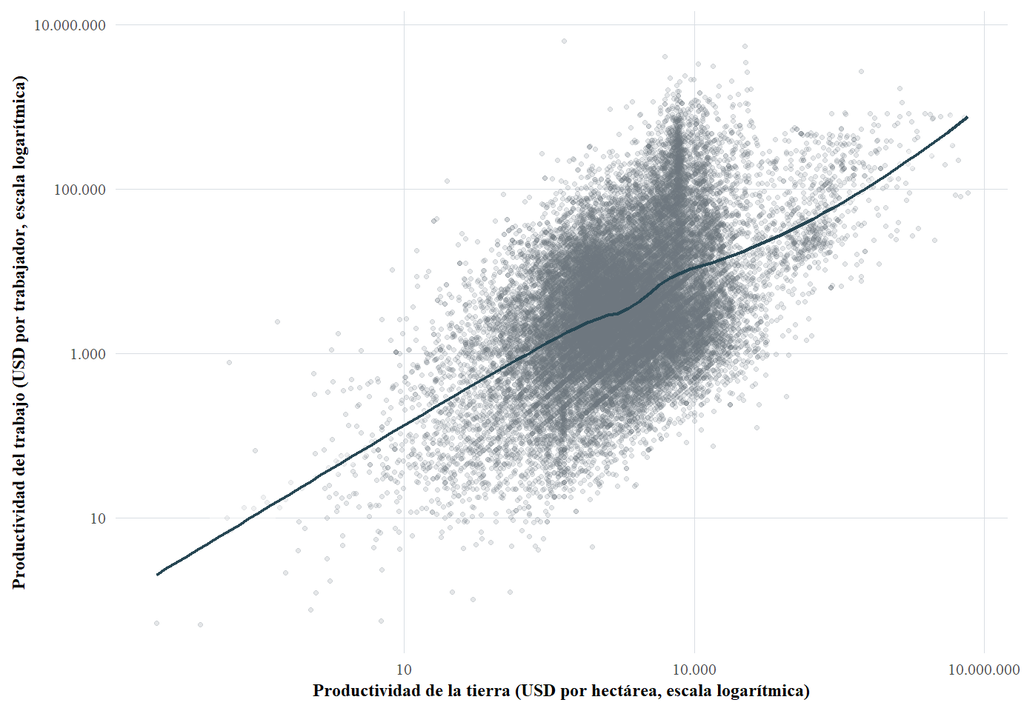

La asociación es positiva, pero la dispersión es amplia: dos UPA con productividad por hectárea similar pueden presentar resultados muy diferentes por trabajador.

## Antes de modelar aparece una primera diferencia

USD/ha

USD/persona

Arrendamiento y aparcería

2.486

4.075

Tenencia directa

1.790

3.275

Otros regímenes

1.503

2.140

En la comparación descriptiva, arrendamiento y aparcería presentan las **mayores medianas** en ambas dimensiones.

**Todavía no es una respuesta causal:** pueden intervenir escala, selección, tecnología, composición productiva y territorio.

Medianas sobre 28.580 UPA con ambas productividades positivas y factor de expansión válido.

## Las medianas difieren, pero las distribuciones se superponen

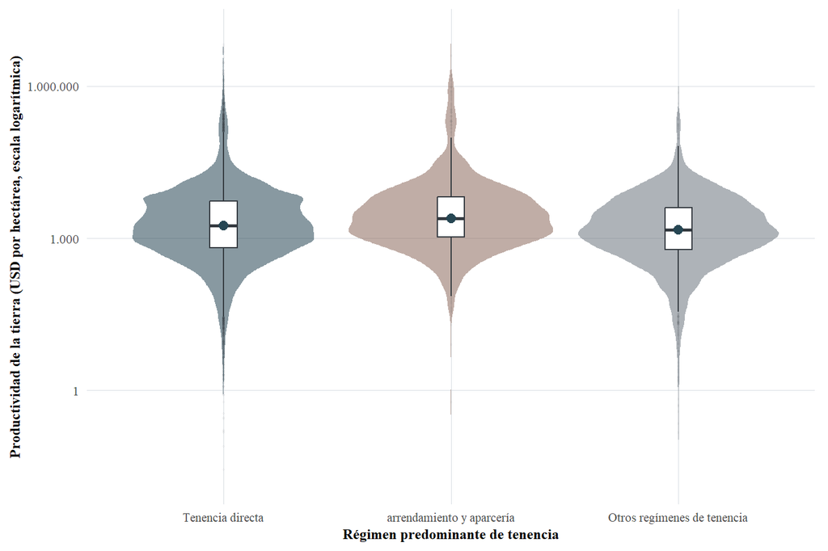

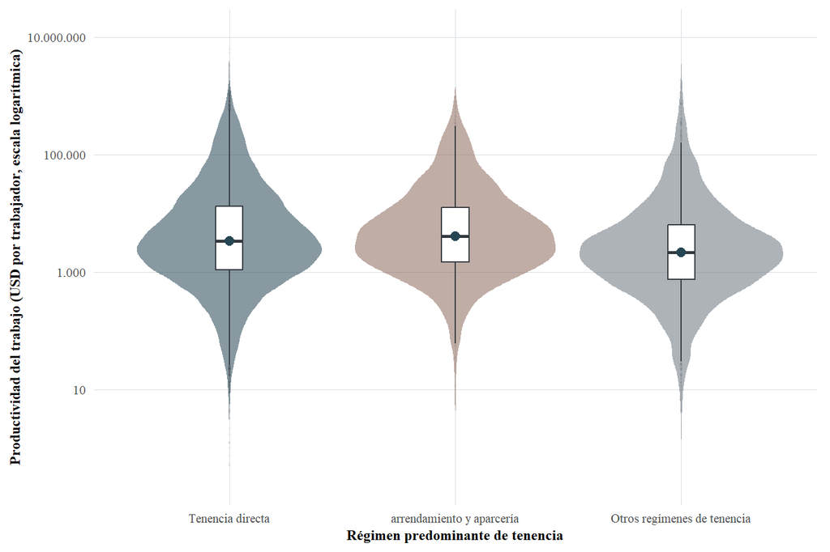

Existe una fuerte **heterogeneidad dentro de cada régimen**; la tenencia no determina por sí sola el desempeño de una UPA.

## La productividad también tiene geografía

Productividad típica de la tierra

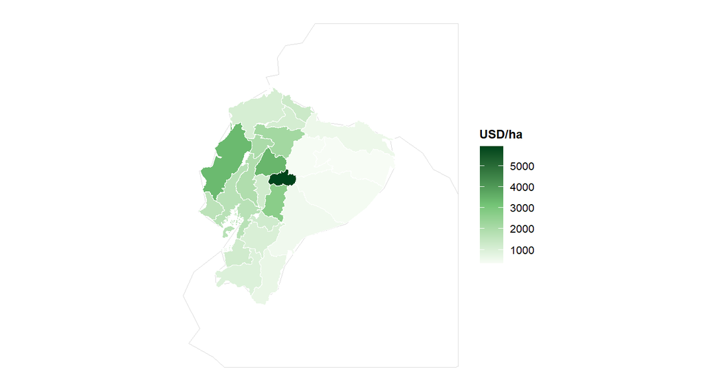

Productividad típica del trabajo

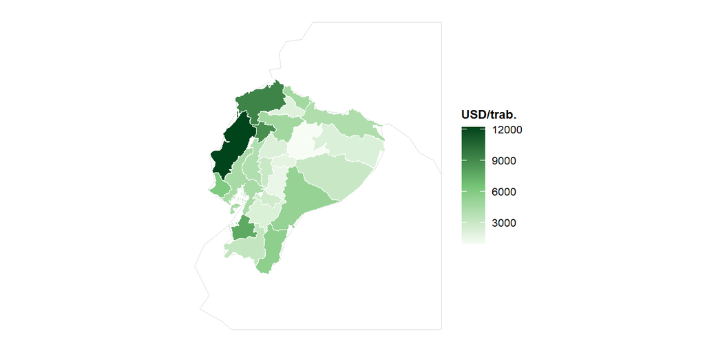

No existe una única geografía productiva: los patrones provinciales cambian según se observe tierra o trabajo.

## OLS + HC1: la asociación persiste al condicionar

### Productividad de la tierra

Tenencia directa**−0,256**

Otros regímenes**−0,446**

### Productividad del trabajo

Tenencia directa**−0,256**

Otros regímenes**−0,415**

Referencia: **arrendamiento y aparcería** · N = 22.075 · errores estándar HC1

Los contrastes frente a arrendamiento y aparcería permanecen **negativos** tras incorporar las covariables observadas.

## La asociación persiste al incorporar información paso a paso

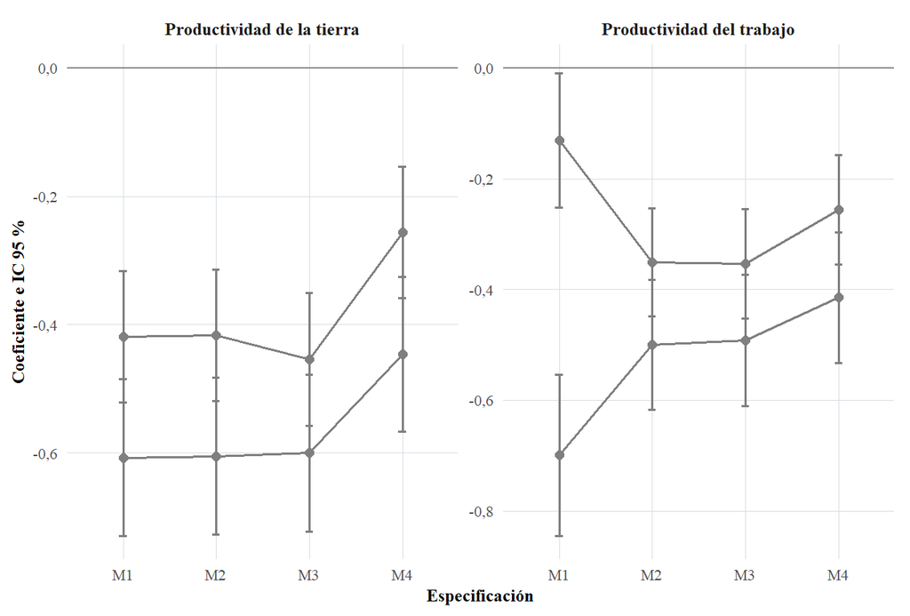

Los coeficientes cambian de magnitud al incorporar controles, pero la **dirección del contraste permanece**.

## La escala importa, pero de manera distinta para tierra y trabajo

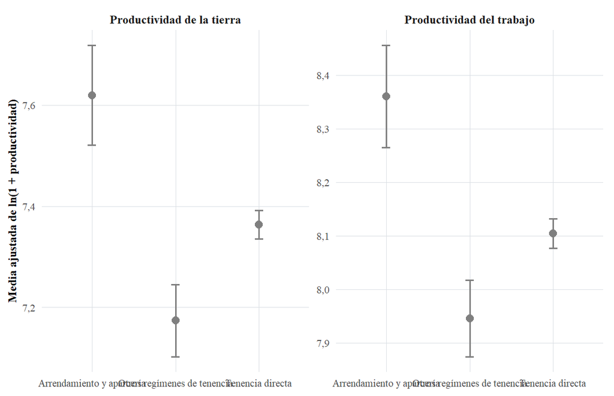

**Tierra**asociación negativa con superficie

**Trabajo**relación positiva, pero cóncava

La escala modifica el desempeño, pero **no elimina la asociación con tenencia** y no opera igual en ambos indicadores.

## Parte de la heterogeneidad está estructurada territorialmente

Modelo nulo

**0,150**Tierra**0,092**Trabajo

→

Modelo completo

**0,118**Tierra**0,114**Trabajo

Incluso después de incorporar covariables, permanece **variación entre provincias**.

## La heterogeneidad provincial permanece después de condicionar

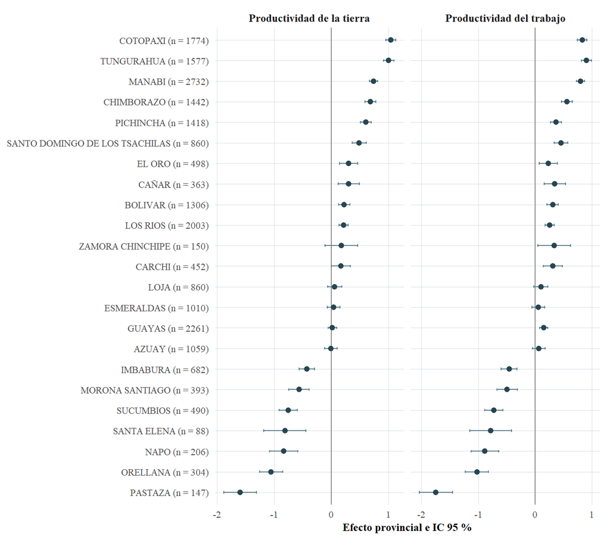

La localización sigue aportando heterogeneidad que las características observadas de las UPA no absorben completamente.

## La asociación con la tenencia es estable frente a dos tratamientos del territorio

| Contraste | Tierra Multinivel | Tierra FE provincia | Trabajo Multinivel | Trabajo FE provincia |
| --- | --- | --- | --- | --- |
| **Tenencia directa** | −0,254 | −0,254 | −0,238 | −0,238 |
| **Otros regímenes** | −0,391 | −0,389 | −0,341 | −0,339 |

Representar provincia con interceptos aleatorios o con efectos fijos produce una **dirección y magnitud muy próximas** para los contrastes de tenencia.

## ¿Qué ocurre si dejamos de mirar solo la media?

### Frontera estocástica

Cambia la pregunta: de la media condicionada a la **posición relativa frente a una frontera monetaria condicionada**.

Tierra **0,404** media · mediana 0,409

Trabajo **0,387** media · mediana 0,392

más lejos de la frontera

más cerca de la frontera

Muestra: **21.430 UPA** · half-normal principal · truncated-normal como sensibilidad.

**No interpretar como “40 % de eficiencia física”.** Son puntuaciones relativas de una frontera de productividad monetaria condicionada, no una función física completa de producción.

## Métodos distintos, una regularidad empírica común

MétodoDirecta · tierraOtros · tierraDirecta · trabajoOtros · trabajo

OLS principal**−0,256****−0,446****−0,256****−0,415**

OLS ponderado**−0,303****−0,449****−0,267****−0,411**

Multinivel**−0,254****−0,391****−0,238****−0,341**

FE provincia**−0,254****−0,389****−0,238****−0,339**

SFA half-normal / truncated-normal: **correlaciones de puntuaciones > 0,98** La magnitud cambia; la **dirección sustantiva permanece**.

## ¿Cómo dialogan estos resultados con la literatura?

### Seguridad formal no es suficiente

**Abdulai · Simbizi**

Derechos consuetudinarios o percibidos también pueden sostener estabilidad e inversión.

### El contexto modifica el resultado

**Lawry et al. (2017)**

Los efectos promedio conviven con una heterogeneidad regional considerable.

### Los mercados pueden reasignar tierra

**Fenske · Otsuka**

El acceso temporal puede ser compatible con reasignación y uso intensivo.

Nuestros resultados son **compatibles** con estos mecanismos; el diseño no identifica cuál de ellos opera causalmente.

## ¿Dónde están las tensiones?

Koirala et al. (2017)

En arroz filipino, los arrendatarios presentan menor productividad y mayor ineficiencia que propietarios.

**Dirección distinta a Ecuador.**

Place et al. (1993)

No encuentra una relación general significativa entre derechos, insumos y rendimientos en determinados contextos africanos.

**La asociación tampoco es universal.**

Feder et al. (1987) · Besley (1995)

Documentan mecanismos favorables ligados a seguridad e inversión.

**Eso no implica superioridad automática de toda tenencia directa.**

Las diferencias entre estudios no son ruido: son evidencia de que **el contexto forma parte del fenómeno**.

## Qué aporta esta tesis

Conceptual

Distingue propiedad, régimen de tenencia y seguridad.

Empírica

Construye evidencia nacional reciente a nivel de UPA.

Medición

Construye y documenta una base de precios 2022 para valorizar producción heterogénea.

Metodológica

Contrasta media condicionada, estructura territorial y frontera estocástica.

La contribución no es un coeficiente aislado: es una **cadena reproducible de medición, contraste e interpretación**.

## Hasta dónde llegan nuestras conclusiones

**2022**corte transversal

**Asociación**no identificación causal

**Tenencia predominante**no calidad contractual completa

**Valor bruto estimado**no beneficio neto

**SFA condicionada**no función física integral de producción

**Covariables observadas**no agotan suelo, clima, mercados ni historia de inversión

Estas restricciones **delimitan la interpretación**; no eliminan la regularidad empírica observada.

## Respuesta final

En la ESPAC 2022 existe una **asociación sistemática** entre régimen predominante de tenencia y las dos dimensiones de productividad analizadas.

Frente a arrendamiento y aparcería, la tenencia directa y los otros regímenes presentan **menores niveles condicionados de productividad** en las especificaciones principales, y esa dirección permanece bajo distintas estrategias de estimación.

La evidencia es **robusta en dirección**, pero **no identifica un efecto causal** del régimen de tenencia.

La forma de acceso a la tierra importa, pero su relación con la productividad no puede entenderse separada de la **escala, las capacidades productivas, la tecnología y el territorio**.

Gracias